# Bellabeat Capstone Project

Anthony Tran

2025-01-15

## Setting up my environment

Notes: We’ll begin by installing and loading the necessary packages to run our analysis:

tidyverse, dplyr, here, janitor, skimr, lubridate, tibble, and waffle.

```r
install.packages("tidyverse")
install.packages("dplyr")
install.packages("here")
install.packages("janitor")
install.packages("skimr")
install.packages("lubridate")
install.packages("tibble")
install.packages("waffle")

library(tidyverse)
library(dplyr)
library(here)
library(janitor)
library(skimr)
library(lubridate)
library(tibble)
library(waffle)
```

## Importing our datasets

Notes: We need to import our various datasets, which are in the form of a .csv, into data frames that we can work with into R.

```r
daily_activity <- read.csv("dailyActivity_merged.csv", header = TRUE)
daily_calories <- read.csv("dailyCalories_merged.csv", header = TRUE)
daily_intensities <- read.csv("dailyIntensities_merged.csv", header = TRUE)
daily_steps <- read.csv("dailySteps_merged.csv", header = TRUE)
sleep_day <- read.csv("sleepDay_merged.csv", header = TRUE)
weight_log <- read.csv("weightLogInfo_merged.csv", header = TRUE)
hourly_steps <- read.csv("hourlySteps_merged.csv", header = TRUE)
hourly_intensity <- read.csv("hourlyIntensities_merged.csv", header = TRUE)
hourly_calories <- read.csv("hourlyCalories_merged.csv", header = TRUE)
```

## Previewing datasets

Notes: Getting a preview and examing the structure of our recently imported datasets for preliminary analysis and planning.

```r
str(daily_activity)
```

```
## 'data.frame':    940 obs. of  15 variables:
##  $ Id                      : num  1.5e+09 1.5e+09 1.5e+09 1.5e+09 1.5e+09 ...
##  $ ActivityDate            : chr  "4/12/2016" "4/13/2016" "4/14/2016" "4/15/2016" ...
##  $ TotalSteps              : int  13162 10735 10460 9762 12669 9705 13019 15506 10544 9819 ...
##  $ TotalDistance           : num  8.5 6.97 6.74 6.28 8.16 ...
##  $ TrackerDistance         : num  8.5 6.97 6.74 6.28 8.16 ...
##  $ LoggedActivitiesDistance: num  0 0 0 0 0 0 0 0 0 0 ...
##  $ VeryActiveDistance      : num  1.88 1.57 2.44 2.14 2.71 ...
##  $ ModeratelyActiveDistance: num  0.55 0.69 0.4 1.26 0.41 ...
##  $ LightActiveDistance     : num  6.06 4.71 3.91 2.83 5.04 ...
##  $ SedentaryActiveDistance : num  0 0 0 0 0 0 0 0 0 0 ...
##  $ VeryActiveMinutes       : int  25 21 30 29 36 38 42 50 28 19 ...
##  $ FairlyActiveMinutes     : int  13 19 11 34 10 20 16 31 12 8 ...
##  $ LightlyActiveMinutes    : int  328 217 181 209 221 164 233 264 205 211 ...
##  $ SedentaryMinutes        : int  728 776 1218 726 773 539 1149 775 818 838 ...
##  $ Calories                : int  1985 1797 1776 1745 1863 1728 1921 2035 1786 1775 ...
```

```r
str(daily_calories)
```

```
## 'data.frame':    940 obs. of  3 variables:
##  $ Id         : num  1.5e+09 1.5e+09 1.5e+09 1.5e+09 1.5e+09 ...
##  $ ActivityDay: chr  "4/12/2016" "4/13/2016" "4/14/2016" "4/15/2016" ...
##  $ Calories   : int  1985 1797 1776 1745 1863 1728 1921 2035 1786 1775 ...
```

```r
str(daily_intensities)
```

```
## 'data.frame':    940 obs. of  10 variables:
##  $ Id                      : num  1.5e+09 1.5e+09 1.5e+09 1.5e+09 1.5e+09 ...
##  $ ActivityDay             : chr  "4/12/2016" "4/13/2016" "4/14/2016" "4/15/2016" ...
##  $ SedentaryMinutes        : int  728 776 1218 726 773 539 1149 775 818 838 ...
##  $ LightlyActiveMinutes    : int  328 217 181 209 221 164 233 264 205 211 ...
##  $ FairlyActiveMinutes     : int  13 19 11 34 10 20 16 31 12 8 ...
##  $ VeryActiveMinutes       : int  25 21 30 29 36 38 42 50 28 19 ...
##  $ SedentaryActiveDistance : num  0 0 0 0 0 0 0 0 0 0 ...
##  $ LightActiveDistance     : num  6.06 4.71 3.91 2.83 5.04 ...
##  $ ModeratelyActiveDistance: num  0.55 0.69 0.4 1.26 0.41 ...
##  $ VeryActiveDistance      : num  1.88 1.57 2.44 2.14 2.71 ...
```

```r
str(daily_steps)
```

```
## 'data.frame':    940 obs. of  3 variables:
##  $ Id         : num  1.5e+09 1.5e+09 1.5e+09 1.5e+09 1.5e+09 ...
##  $ ActivityDay: chr  "4/12/2016" "4/13/2016" "4/14/2016" "4/15/2016" ...
##  $ StepTotal  : int  13162 10735 10460 9762 12669 9705 13019 15506 10544 9819 ...
```

```r
str(sleep_day)
```

```
## 'data.frame':    413 obs. of  5 variables:
##  $ Id                : num  1.5e+09 1.5e+09 1.5e+09 1.5e+09 1.5e+09 ...
##  $ SleepDay          : chr  "4/12/2016 12:00:00 AM" "4/13/2016 12:00:00 AM" "4/15/2016 12:00:00 AM" "4/16/2016 12:00:00 AM" ...
##  $ TotalSleepRecords : int  1 2 1 2 1 1 1 1 1 1 ...
##  $ TotalMinutesAsleep: int  327 384 412 340 700 304 360 325 361 430 ...
##  $ TotalTimeInBed    : int  346 407 442 367 712 320 377 364 384 449 ...
```

```r
str(weight_log)
```

```
## 'data.frame':    67 obs. of  8 variables:
##  $ Id            : num  1.50e+09 1.50e+09 1.93e+09 2.87e+09 2.87e+09 ...
##  $ Date          : chr  "5/2/2016 11:59:59 PM" "5/3/2016 11:59:59 PM" "4/13/2016 1:08:52 AM" "4/21/2016 11:59:59 PM" ...
##  $ WeightKg      : num  52.6 52.6 133.5 56.7 57.3 ...
##  $ WeightPounds  : num  116 116 294 125 126 ...
##  $ Fat           : int  22 NA NA NA NA 25 NA NA NA NA ...
##  $ BMI           : num  22.6 22.6 47.5 21.5 21.7 ...
##  $ IsManualReport: chr  "True" "True" "False" "True" ...
##  $ LogId         : num  1.46e+12 1.46e+12 1.46e+12 1.46e+12 1.46e+12 ...
```

```r
str(hourly_steps)
```

```
## 'data.frame':    22099 obs. of  3 variables:
##  $ Id          : num  1.5e+09 1.5e+09 1.5e+09 1.5e+09 1.5e+09 ...
##  $ ActivityHour: chr  "4/12/2016 12:00:00 AM" "4/12/2016 1:00:00 AM" "4/12/2016 2:00:00 AM" "4/12/2016 3:00:00 AM" ...
##  $ StepTotal   : int  373 160 151 0 0 0 0 0 250 1864 ...
```

```r
str(hourly_intensity)
```

```
## 'data.frame':    22099 obs. of  4 variables:
##  $ Id              : num  1.5e+09 1.5e+09 1.5e+09 1.5e+09 1.5e+09 ...
##  $ ActivityHour    : chr  "4/12/2016 12:00:00 AM" "4/12/2016 1:00:00 AM" "4/12/2016 2:00:00 AM" "4/12/2016 3:00:00 AM" ...
##  $ TotalIntensity  : int  20 8 7 0 0 0 0 0 13 30 ...
##  $ AverageIntensity: num  0.333 0.133 0.117 0 0 ...
```

```r
str(hourly_calories)
```

```
## 'data.frame':    22099 obs. of  3 variables:
##  $ Id          : num  1.5e+09 1.5e+09 1.5e+09 1.5e+09 1.5e+09 ...
##  $ ActivityHour: chr  "4/12/2016 12:00:00 AM" "4/12/2016 1:00:00 AM" "4/12/2016 2:00:00 AM" "4/12/2016 3:00:00 AM" ...
##  $ Calories    : int  81 61 59 47 48 48 48 47 68 141 ...
```

Upon examining the data frames and column names, we see that daily_activities also contains the complete data set for daily_calories, daily_intensities, and daily_steps as well.

So from now on when using the data for daily_calories, daily_intensities, and daily_steps, I will reference their respective columns from the daily_activity data frame for simplicity.

## Verifying sample size

Notes: Counting how many distinct participants we have for each dataset, and whether it is appropriate to use for our analysis.

```r
n_distinct(daily_activity$Id)
```

```
## [1] 33
```

```r
n_distinct(daily_calories$Id)
```

```
## [1] 33
```

```r
n_distinct(daily_intensities$Id)
```

```
## [1] 33
```

```r
n_distinct(daily_steps$Id)
```

```
## [1] 33
```

```r
n_distinct(sleep_day$Id)
```

```
## [1] 24
```

```r
n_distinct(weight_log$Id)
```

```
## [1] 8
```

```r
n_distinct(hourly_steps$Id)
```

```
## [1] 33
```

```r
n_distinct(hourly_intensity$Id)
```

```
## [1] 33
```

```r
n_distinct(hourly_calories$Id)
```

```
## [1] 33
```

In statistics, there is a “rule of 30,” where 30 is typically the minimum sample size needed to make a statistically strong conclusion about the data. So because of this I will discard the weight data, which only has 8 people. Sleep has 24 participants, but I will still run a preliminary analysis on it regardless, with that in consideration.

## Converting into proper date format

We also see from the previous section that the dates are in character format, so we will need to convert to proper date or date/time format, and hide the old columns.

This is so our packages will be able to properly run on it.

```r
daily_activity <- daily_activity %>%
  mutate(ActivityDate = mdy(ActivityDate))
hourly_steps <- hourly_steps %>%
  mutate(ActivityDateHour = mdy_hms(ActivityHour)) %>%
  select(-ActivityHour)
hourly_intensity <- hourly_intensity %>%
  mutate(ActivityDateHour = mdy_hms(ActivityHour)) %>%
  select(-ActivityHour)
hourly_calories <- hourly_calories %>%
  mutate(ActivityDateHour = mdy_hms(ActivityHour)) %>%
  select(-ActivityHour)
sleep_day <- sleep_day %>%
  mutate(SleepDate = as.Date(mdy_hms(SleepDay))) %>%
  select(-SleepDay)
```

## Verifying the values were properly changed from character to date & date/time.

```r
class(daily_activity$ActivityDate)
```

```
## [1] "Date"
```

```r
class(hourly_steps$ActivityDateHour)
```

```
## [1] "POSIXct" "POSIXt"
```

```r
class(hourly_intensity$ActivityDateHour)
```

```
## [1] "POSIXct" "POSIXt"
```

```r
class(hourly_calories$ActivityDateHour)
```

```
## [1] "POSIXct" "POSIXt"
```

```r
class(sleep_day$SleepDate)
```

```
## [1] "Date"
```

## Cleaning the data

Notes: Each data frame was manually imported and assigned the appropriate naming convention by me in snakecase.

Next we will check for errors and inconsistencies in the data by checking for duplicated records and missing values.

```r
sum(duplicated(daily_activity))
```

```
## [1] 0
```

```r
sum(duplicated(sleep_day))
```

```
## [1] 3
```

```r
sum(duplicated(hourly_steps))
```

```
## [1] 0
```

```r
sum(duplicated(hourly_calories))
```

```
## [1] 0
```

```r
sum(duplicated(hourly_intensity))
```

```
## [1] 0
```

```r
sum(is.na(daily_activity))
```

```
## [1] 0
```

```r
sum(is.na(sleep_day))
```

```
## [1] 0
```

```r
sum(is.na(hourly_steps))
```

```
## [1] 0
```

```r
sum(is.na(hourly_calories))
```

```
## [1] 0
```

```r
sum(is.na(hourly_intensity))
```

```
## [1] 0
```

sleep_day has 3 duplicated records. All other datasets passed the initial check.

## Get rid of duplicated observations, and drop missing values from data frames as needed.

```r
daily_activity <- daily_activity %>%
  distinct %>%
  drop_na
sleep_day <-sleep_day %>%
  distinct %>%
  drop_na
hourly_steps <- hourly_steps %>%
  distinct %>%
  drop_na
hourly_calories <- hourly_calories %>%
  distinct %>%
  drop_na
hourly_intensity <- hourly_intensity %>%
  distinct %>%
  drop_na
```

## Merge to create a new combined data frame, and verify distinct users.

```r
daily_activity_sleep <- merge(daily_activity, sleep_day, by.x = c("Id", "ActivityDate"), by.y = c("Id", "SleepDate"), all = TRUE)

n_distinct(daily_activity_sleep$Id)
```

```
## [1] 33
```

Here we are creating a new merged data frame for one of our analyses.

# **Analyze and share phase:**

## Basic overview summary:

Notes: Some basic preliminary summary analysis

```r
daily_activity %>%
  select(TotalSteps, Calories, SedentaryMinutes) %>%
  summary()
```

```
##    TotalSteps       Calories    SedentaryMinutes
##  Min.   :    0   Min.   :   0   Min.   :   0.0
##  1st Qu.: 3790   1st Qu.:1828   1st Qu.: 729.8
##  Median : 7406   Median :2134   Median :1057.5
##  Mean   : 7638   Mean   :2304   Mean   : 991.2
##  3rd Qu.:10727   3rd Qu.:2793   3rd Qu.:1229.5
##  Max.   :36019   Max.   :4900   Max.   :1440.0
```

```r
sleep_day %>%
  select(TotalSleepRecords, TotalMinutesAsleep, TotalTimeInBed) %>%
  summary()
```

```
##  TotalSleepRecords TotalMinutesAsleep TotalTimeInBed
##  Min.   :1.00      Min.   : 58.0      Min.   : 61.0
##  1st Qu.:1.00      1st Qu.:361.0      1st Qu.:403.8
##  Median :1.00      Median :432.5      Median :463.0
##  Mean   :1.12      Mean   :419.2      Mean   :458.5
##  3rd Qu.:1.00      3rd Qu.:490.0      3rd Qu.:526.0
##  Max.   :3.00      Max.   :796.0      Max.   :961.0
```

```r
hourly_steps %>%
  select(StepTotal) %>%
  filter(StepTotal != 0) %>%
  summary()
```

```
##    StepTotal
##  Min.   :    1.0
##  1st Qu.:  103.0
##  Median :  287.0
##  Mean   :  552.7
##  3rd Qu.:  643.0
##  Max.   :10554.0
```

```r
hourly_calories %>%
  select(Calories) %>%
  summary()
```

```
##     Calories
##  Min.   : 42.00
##  1st Qu.: 63.00
##  Median : 83.00
##  Mean   : 97.39
##  3rd Qu.:108.00
##  Max.   :948.00
```

```r
hourly_intensity %>%
  select(TotalIntensity, AverageIntensity) %>%
  summary()
```

```
##  TotalIntensity   AverageIntensity
##  Min.   :  0.00   Min.   :0.0000
##  1st Qu.:  0.00   1st Qu.:0.0000
##  Median :  3.00   Median :0.0500
##  Mean   : 12.04   Mean   :0.2006
##  3rd Qu.: 16.00   3rd Qu.:0.2667
##  Max.   :180.00   Max.   :3.0000
```

- The Center for Disease Control (CDC) recommends that the average adult take around 8,000-10,000+ steps per day. Compared to our data showing the mean and median daily steps at 7638 and 7406, respectively. Adults are not being as active as they should be. One premature recommendation is a device feature reminding people to get up and be active/walk around once in a while, after a certain amount of sedentary minutes has elapsed.
- The National Institute of Health (NIH) recommends that adults get between 7 and 9 hours of sleep per night. The average sleep time for our group here is just around 7 hours, barely at the lower end of the minimum. The data shows that this sample does not meet the recommended goal. We can use this as an opportunity to add a feature to our device that reminds users to go to bed at a reasonable time, given what time they wake up. As well as add in these recommendations from government institutions as a credible source to help persuade people to comply.
- The average number of hourly steps during waking hours for the participants in our study is 552.7 steps, with a median of 287.0. This indicates the data is skewed to the right.
- The average number of hourly calories burned for our study participants is ~98 calories.
- The median hourly total intensity for the FitBit users is 3.00, with a mean of 12.04, also indicating the data is skewed right.

## Let days where users used at least one functionality of the device count as an “active day.”

Out of a possible 31 days.

Let us classify usage days as:

- 0-10 Low usage
- 11-20 Medium usage
- 21-31 High usage

```r
usage_counts <- daily_activity_sleep %>%
  group_by(Id) %>%
  summarise(days_active = n_distinct(ActivityDate)) %>%
  mutate(device_usage = case_when(
    days_active >= 0 & days_active <= 10 ~ "Low Usage",
    days_active >= 11 & days_active <= 20 ~ "Medium Usage",
    days_active >= 21 & days_active <= 31 ~ "High Usage"
  )) %>%
  group_by(device_usage) %>%
  count(device_usage)

print(usage_counts)
```

```
## # A tibble: 3 × 2
## # Groups:   device_usage [3]
##   device_usage     n
##   <chr>        <int>
## 1 High Usage      29
## 2 Low Usage        1
## 3 Medium Usage     3
```

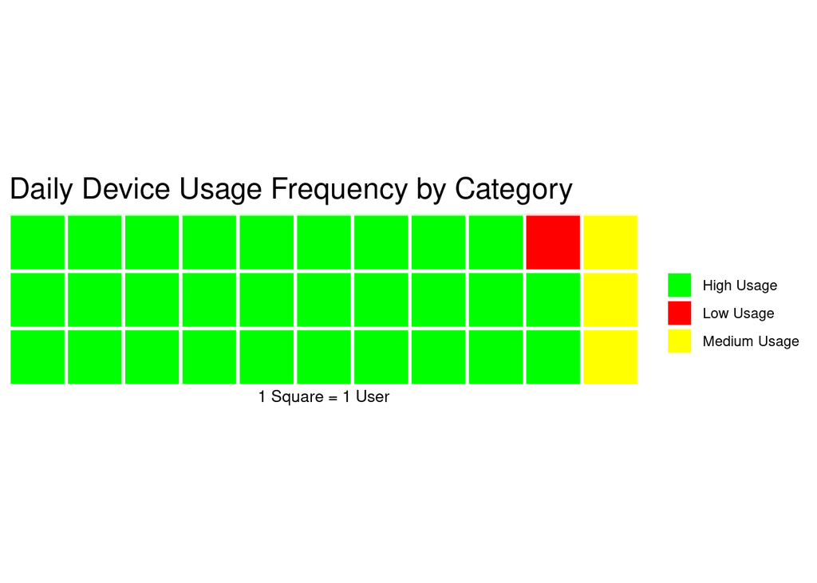

```r
  waffle_data <- setNames(usage_counts$n, usage_counts$device_usage)
waffle(waffle_data,
       rows = 3,
       xlab = "1 Square = 1 User",
       title = "Daily Device Usage Frequency by Category",
       colors = c("green", "red", "yellow"),
       size = 1,
       legend_pos = "right")
```

- The majority of our sample participants have engaged with their device at least once per day, most fitting into our criteria of “high usage,” which is at least over 2/3rds of the total study period of 31 days.
- We can market more premium subscription tiers for the high usage class who are clearly into their health metrics. Possibly one that offers more metrics, recommendations, and reminders.
- Can we determine how we can get the low/medium usage groups to engage more often?
- What are the reasons behind the low usage group and is it worth looking into?

## Visualizations

What else can we interpret from creating some visuals?

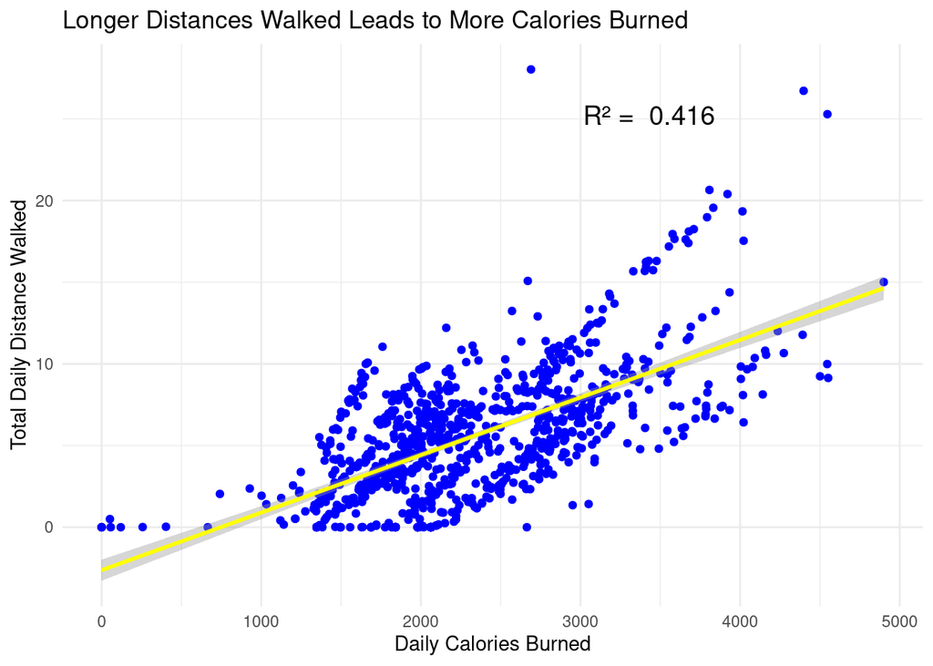

```r
model <- lm(TotalDistance ~ Calories, data = na.omit(daily_activity))
r_squared <- summary(model)$r.squared
ggplot(data = na.omit(daily_activity), aes(x = Calories, y = TotalDistance)) +
  geom_point(color = "blue") +
  geom_smooth(method = "lm", color = "yellow") +
  labs(title = "Longer Distances Walked Leads to More Calories Burned",
       x = "Daily Calories Burned",
       y = "Total Daily Distance Walked") +
  theme_minimal() +
  annotate("text", x = max(na.omit(daily_activity)$Calories) * 0.7,
           y = max(na.omit(daily_activity)$TotalDistance) * 0.9,
           label = paste("R² = ", round(r_squared, 3)), size = 5, color = "black")
```

- The general trend here is that there is a positive correlation between total daily distance walked and daily calories burned. We can include this information in an pop-up reminder for the user to be aware of, if that’s their goal.

[figure not shown]

```r
sleep_day_of_week <- sleep_day %>%
  mutate(day_of_week = wday(SleepDate, label = TRUE, abbr = FALSE))
average_sleep_per_day <- sleep_day_of_week %>%
  group_by(day_of_week) %>%
  summarise(average_sleep_time = mean(TotalMinutesAsleep, na.rm = TRUE)) %>%
  arrange(match(day_of_week, c("Monday", "Tuesday", "Wednesday", "Thursday", "Friday", "Saturday", "Sunday")))
ggplot(average_sleep_per_day, aes(x = day_of_week, y = average_sleep_time, fill = day_of_week)) +
  geom_col() +
  labs( title = "Why Do People Sleep More on Wednesdays?", x = "Day of the Week", y = "Average Sleep Time (minutes)") +
  theme_minimal() +
  theme(axis.text.x = element_text(angle = 45, hjust = 1))
```

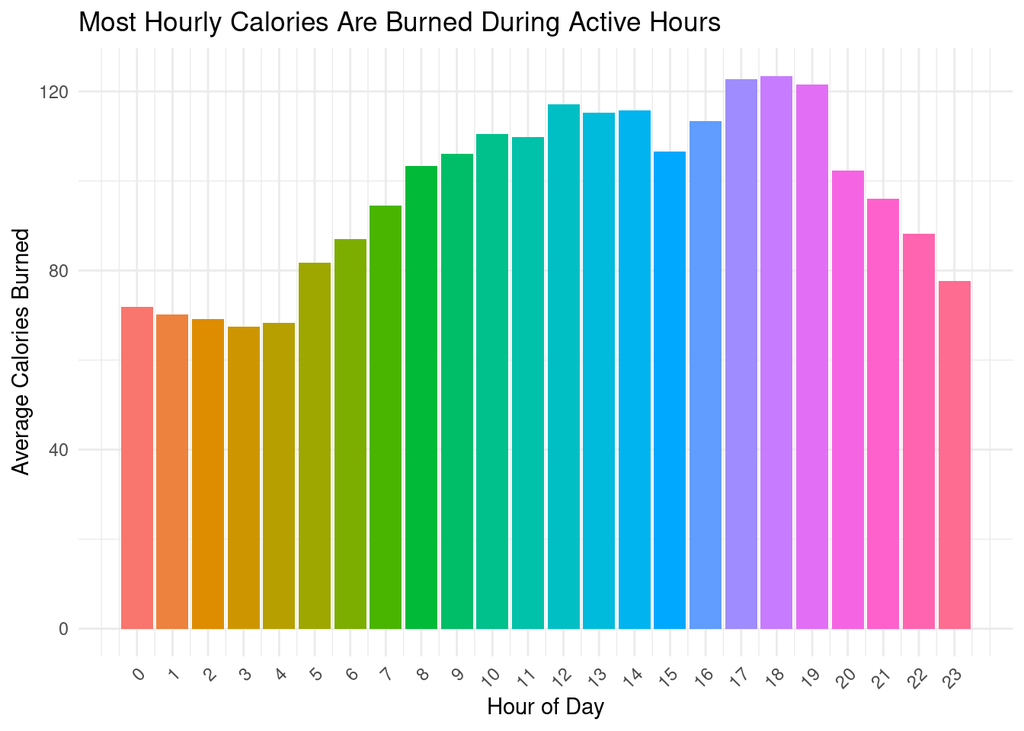

```r
hourly_calories_by_hour <- hourly_calories %>%
  mutate(hour_of_day = hour(ActivityDateHour))
average_hourly_calories <- hourly_calories_by_hour %>%
  group_by(hour_of_day) %>%
  summarise(average_calories = mean(Calories, na.rm = TRUE)) %>%
  arrange(hour_of_day)
ggplot(average_hourly_calories, aes(x = hour_of_day, y = average_calories, fill = factor(hour_of_day))) +
  geom_bar(stat = "identity", show.legend = FALSE) +
  labs(title = "Most Hourly Calories Are Burned During Active Hours",
       x = "Hour of Day",
       y = "Average Calories Burned" ) +
  theme_minimal() +
  scale_x_continuous(breaks = 0:23) +
  theme(axis.text.x = element_text(angle = 45, hjust = 1))
```

- The most active hours of the day are during the waking hours, with the calories burned gradually ramping up hourly before coming back down towards the end of the day.

```r
hourly_intensity_by_hour <- hourly_intensity %>%
  mutate( hour_of_day = hour(ActivityDateHour),
          day_type = if_else(wday(ActivityDateHour, label = TRUE) %in% c("Sat", "Sun"), "Weekend", "Weekday"))
average_hourly_intensity_by_weekend_weekday <- hourly_intensity_by_hour %>%
  group_by(day_type, hour_of_day) %>% summarise(mean_intensity_hour = mean(TotalIntensity, na.rm = TRUE)) %>%
  arrange(factor(day_type, levels = c("Weekday", "Weekend")), hour_of_day)
```

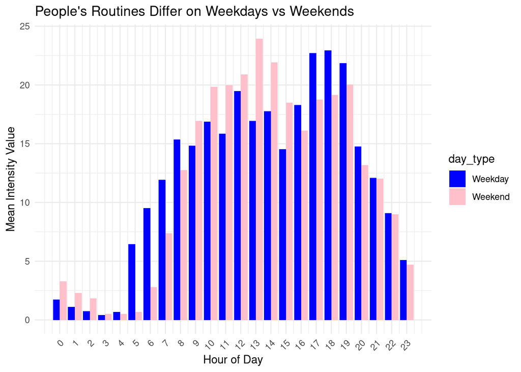

```r
ggplot(average_hourly_intensity_by_weekend_weekday, aes(x = hour_of_day, y = mean_intensity_hour, fill = day_type)) +
  geom_bar(stat = "identity", position = "dodge") +
  labs( title = "People's Routines Differ on Weekdays vs Weekends",
        x = "Hour of Day",
        y = "Mean Intensity Value" ) +
  scale_x_continuous(breaks = 0:23) +
  scale_fill_manual(values = c("Weekday" = "blue", "Weekend" = "pink")) +
  theme_minimal() +
  theme(axis.text.x = element_text(angle = 45, hjust = 1))
```

- People have different schedules/routines on the weekend vs weekday.

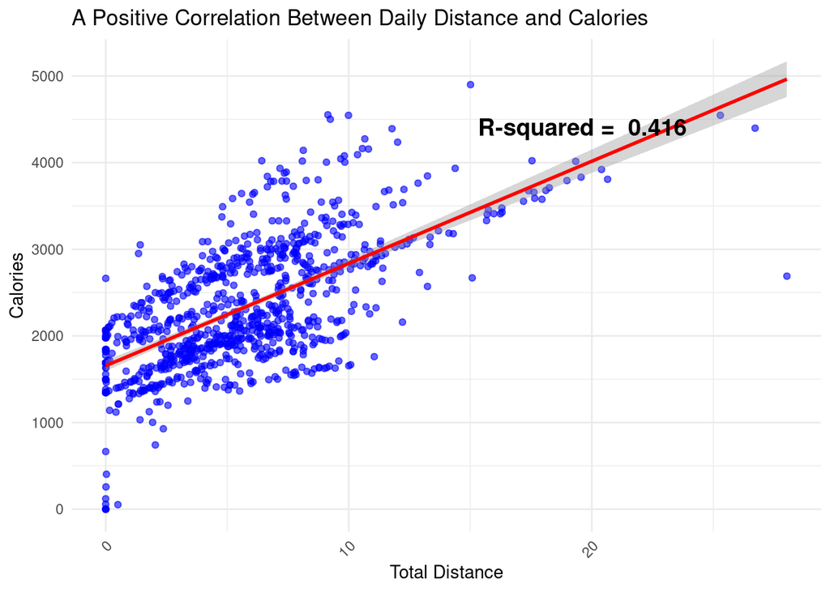

```r
distance_calories_model <- lm(Calories ~ TotalDistance, data = daily_activity)
distance_calories_r_squared <- summary(distance_calories_model)$r.squared
ggplot(daily_activity, aes(x = TotalDistance, y = Calories)) +
  geom_point(alpha = 0.6, color = "blue") +
  geom_smooth(method = "lm", color = "red", linewidth = 1) +
  labs(title = "A Positive Correlation Between Daily Distance and Calories",
       x = "Total Distance",
       y = "Calories") +
  annotate("text", x = max(daily_activity$TotalDistance) * 0.7,
           y = max(daily_activity$Calories) * 0.9,
           label = paste("R-squared = ", round(distance_calories_r_squared, 3)),
           color = "black", size = 5, fontface = "bold") +
  theme_minimal() +
  theme(axis.text.x = element_text(angle = 45, hjust = 1))
```

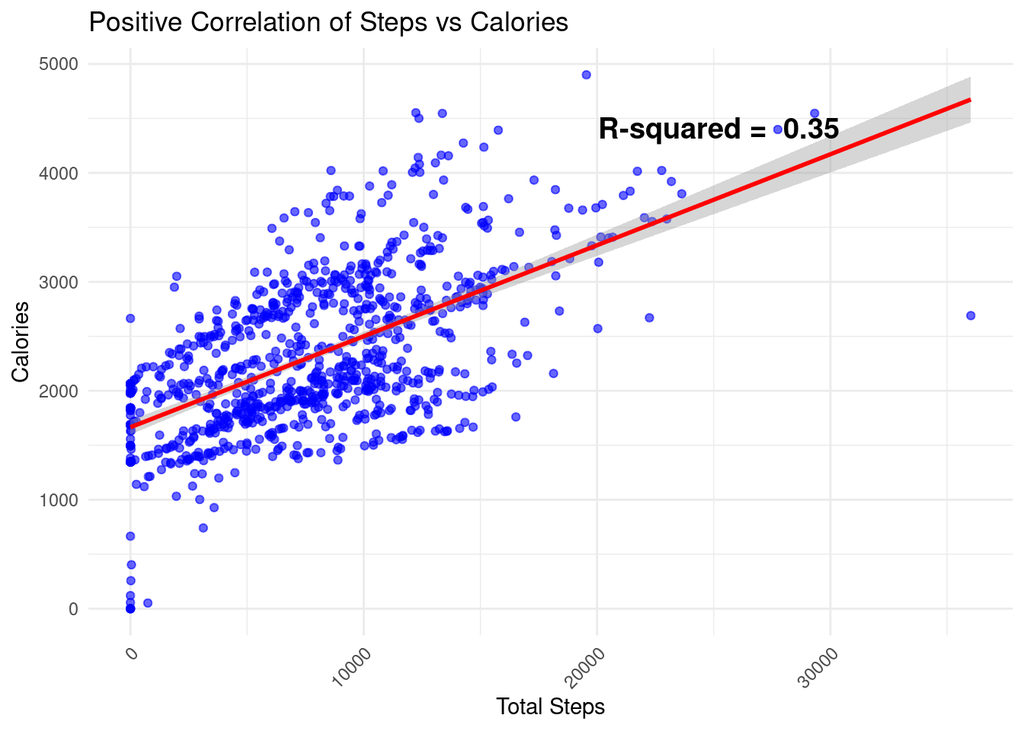

```r
steps_calories_model <- lm(Calories ~ TotalSteps, data = daily_activity)
steps_calories_r_squared <- summary(steps_calories_model)$r.squared
ggplot(daily_activity, aes(x = TotalSteps, y = Calories)) +
  geom_point(alpha = 0.6, color = "blue") +
  geom_smooth(method = "lm", color = "red", linewidth = 1) +
  labs(title = "Positive Correlation of Steps vs Calories",
       x = "Total Steps",
       y = "Calories") +
  annotate("text", x = max(daily_activity$TotalSteps) * 0.7,
           y = max(daily_activity$Calories) * 0.9,
           label = paste("R-squared = ", round(steps_calories_r_squared, 3)),
           color = "black", size = 5, fontface = "bold") +
  theme_minimal() +
  theme(axis.text.x = element_text(angle = 45, hjust = 1))
```

- Both these metrics have similar predictive correlations for calories burned.

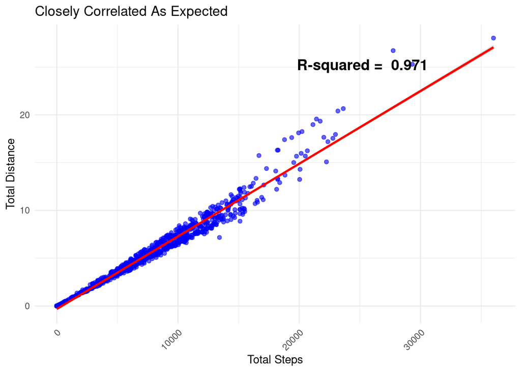

```r
steps_distance_model <- lm(TotalDistance ~ TotalSteps, data = daily_activity)
steps_distance_r_squared <- summary(steps_distance_model)$r.squared
ggplot(daily_activity, aes(x = TotalSteps, y = TotalDistance)) +
  geom_point(alpha = 0.6, color = "blue") +
  geom_smooth(method = "lm", color = "red", linewidth = 1) +
  labs(title = "Closely Correlated As Expected",
       x = "Total Steps",
       y = "Total Distance") +
  annotate("text", x = max(daily_activity$TotalSteps) * 0.7,
           y = max(daily_activity$TotalDistance) * 0.9,
           label = paste("R-squared = ", round(steps_distance_r_squared, 3)),
           color = "black", size = 5, fontface = "bold") +
  theme_minimal() +
  theme(axis.text.x = element_text(angle = 45, hjust = 1))
```

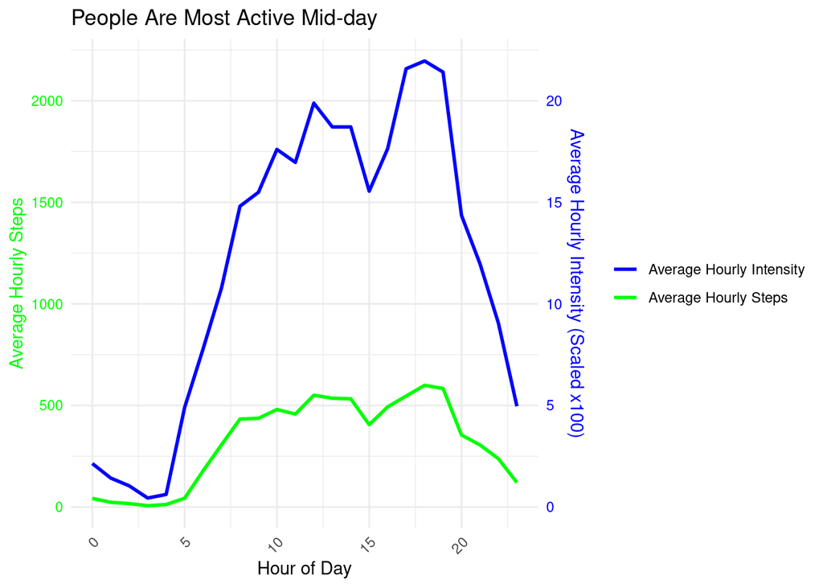

```r
average_hourly_steps_intensity_merged <- hourly_steps %>%
  merge(hourly_intensity, by = "ActivityDateHour") %>%
  group_by(hour = hour(ActivityDateHour)) %>%
  summarise(
    average_hourly_steps = mean(StepTotal, na.rm = TRUE),
    average_hourly_intensity = mean(TotalIntensity, na.rm = TRUE)
  ) %>%
  arrange(hour)


ggplot(average_hourly_steps_intensity_merged, aes(x = hour)) +
  geom_line(aes(y = average_hourly_steps, color = "Average Hourly Steps"), size = 1) +
  geom_line(aes(y = average_hourly_intensity * 100, color = "Average Hourly Intensity"), size = 1) +
  scale_y_continuous(
    name = "Average Hourly Steps",
    sec.axis = sec_axis(~ . / 100, name = "Average Hourly Intensity (Scaled x100)")
  ) +
  labs(
    title = "People Are Most Active Mid-day",
    x = "Hour of Day"
  ) +
  theme_minimal() +
  theme(
    axis.text.x = element_text(angle = 45, hjust = 1),
    axis.title.y.right = element_text(color = "blue"),
    axis.text.y.right = element_text(color = "blue"),
    axis.title.y.left = element_text(color = "green"),
    axis.text.y.left = element_text(color = "green")
  ) +
  scale_color_manual(values = c("Average Hourly Steps" = "green", "Average Hourly Intensity" = "blue")) +
  theme(legend.title = element_blank())
```

- Both hourly steps and intensity follow a similar trend of ramping up mid-day.

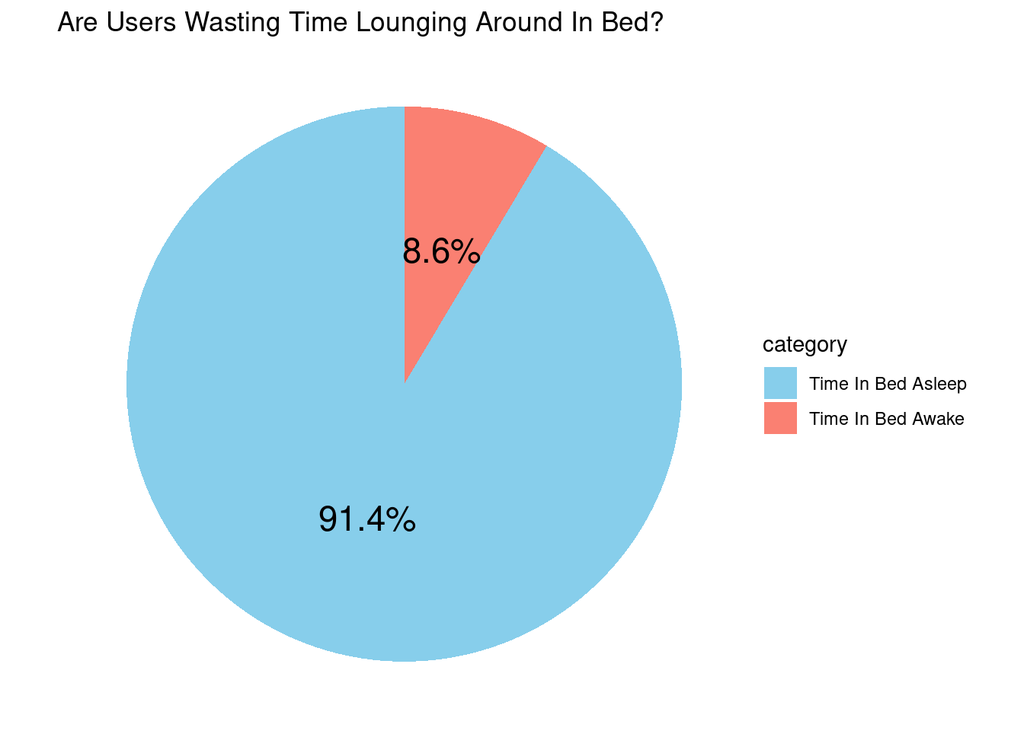

```r
percent_time_in_bed_sleeping <- sleep_day %>%
  summarise( sum_total_minutes_asleep = sum(TotalMinutesAsleep, na.rm = TRUE),
             sum_total_time_in_bed = sum(TotalTimeInBed, na.rm = TRUE),
             percentage_asleep = (sum_total_minutes_asleep / sum_total_time_in_bed) * 100,
             percentage_awake = 100 - percentage_asleep)

percent_sleep_pie <- data.frame(
  category = c("Time In Bed Asleep", "Time In Bed Awake"),
  percentage = c(percent_time_in_bed_sleeping$percentage_asleep,
                 percent_time_in_bed_sleeping$percentage_awake) )

ggplot(percent_sleep_pie, aes(x = "", y = percentage, fill = category)) +
  geom_bar(stat = "identity", width = 1) +
  coord_polar(theta = "y") +
  labs(title = "Are Users Wasting Time Lounging Around In Bed?") +
  theme_void() +  # Remove background grid
  scale_fill_manual(values = c("skyblue", "salmon")) +
  geom_text(aes(label = paste0(round(percentage, 1), "%")),
            position = position_stack(vjust = 0.5),
            color = "black", size = 6)
```

- Here we have percent time spent sleeping as a function of total time spent in bed, on average between all individual users.
- As a whole, it looks like users are not getting distracted and having a hard time falling asleep.
- If they did spend more time awake in bed, we could possibly implement a feature to try and remind users to stop all activity and focus on trying to sleep if they want to hit their scheduled hours of sleep goal, for those who need or want it.